# *Análisis de puntos de corte en las series de tiempo de nacidos vivos, mediante el uso de Facebook Prophet*

En este notebook se realiza la lectura de los datos de nacidos vivos registrados en los años 2011 a 2018. El archivo contiene los datos de todos los nacidos vivos de Argentina, con las variables fecnac: fecha de nacimiento, gedad: grupo de edad de la madre provres: provincia de residencia de la madre, depres: departamento de residencia de la madre, minstruc: nivel de instrucción, masociad: afiliacion a un sistema de atención de la salud, ocloc: local de ocurrencia del nacimiento, totemb total de embarazos ano: año de registro de la información.

Para garantizar la confidencialidad, se han convertido en el archivo csv original todos los valores de departamento a 999 y el total de embarazos a 99. Las variables finales a usar se definirán con el tutor del TFI. Para la aplicación del modelo con Prophet se usarán solo algunas de las variables.

**Secuencia de pasos en que se realiza el análisis**

1. Lectura de los datos, realización de EDA básico. Selecciono provincias y asigna valores a los valores missing en las variables grupo de edad, local de ocurrencia y afiliación a sistemas de atención.
2. Creación de una nueva variable "cobertura de salud" a partir de afiliación y lugar de ocurrencia. Dado que una mujer no afiliada puede ser por no tener cobertura o por tener capacidad para hacer pago privado, se combina la variable no afiliada con ocurrencia en hospital público para construir la categoría "sin cobertura de salud"
3. Se genera un nuevo dataframe con variable cobertura y fechas y se almacena como csv
4. Análisis de las series de tiempo: gráficos exploratorios para el período 2011 a 2017 (fechas de ocurrencia del nacimiento, no de registro)
5. Aplicación del modelo de serie mensual con PROPHET para detectar los puntos de cambio

**Librerías que se utilizan:** pandas matplotlib.pyplot numpy seaborn fbprohet **Se utilizó la version 3.8.2 de 64 bit de Python**

# 1. Lectura de datos, EDA y asignación missing

```python
# cargo las librerias que necesito
import os
import pandas as pd
import matplotlib.pyplot as plt
import numpy as np
import seaborn as sns
```

```python
# seteo el directorio mio de trabajo
os.chdir("d:/ITBA/seminario")
```

```python
# Creo directorios donde se guardan los resultados, si no existen

directorio1 = "d:/ITBA/seminario/salidas/graficos/CABA/"
directorio2 = "d:/ITBA/seminario/salidas/graficos/Mendoza/"
directorio3 = "d:/ITBA/seminario/salidas/resultados/CABA/"
directorio4 = "d:/ITBA/seminario/salidas/resultados/Mendoza/"
directorios=(directorio1,directorio2,directorio3,directorio4)
for directorio in directorios:
    try:
      os.stat(directorio)
    except:
      os.mkdir(directorio)
```

```python
#  Leo el arhcivo de datos de nacidos vivos de 2011 a 2018 asignando los valores faltantes
missing_values = ["9", "99", "999"]
datos = pd.read_csv('datasets/nacidos.csv',na_values = missing_values,sep=" ")
datos.head()
```

|  | fecnac | gedad | provres | depres | minstruc | masociad | ocloc | totemb | año |
| --- | --- | --- | --- | --- | --- | --- | --- | --- | --- |
| 0 | 14/02/2018 | 25.0 | 82.0 | NaN | 4.0 | 1.0 | 2.0 | NaN | 2018 |
| 1 | 14/02/2018 | 30.0 | 82.0 | NaN | 3.0 | 4.0 | 1.0 | NaN | 2018 |
| 2 | 05/02/2018 | 20.0 | 82.0 | NaN | 5.0 | 4.0 | 2.0 | NaN | 2018 |
| 3 | 25/01/2018 | 15.0 | 82.0 | NaN | 4.0 | 4.0 | 1.0 | NaN | 2018 |
| 4 | 13/02/2018 | 15.0 | 82.0 | NaN | 3.0 | 4.0 | 2.0 | NaN | 2018 |

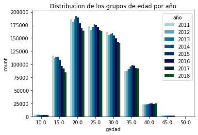

```python
ax = sns.countplot(x="gedad",hue="año", data=datos,palette='ocean_r').set_title('Distribucion de los grupos de edad por año')
```

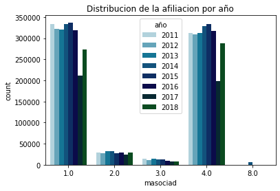

```python
ax = sns.countplot(x="masociad",hue="año", data=datos,palette='ocean_r').set_title('Distribucion de la afiliacion por año')
```

**Se observa una caída importante en el año 2017 de casos tanto en categoria 1 como 4, esto se debe a que pcia de Buenos Aires no informó esa variable**

[figure not shown]

```python
ax = sns.countplot(x="ocloc",hue="año", data=datos,palette='ocean_r').set_title('Distribucion de la ocurrencia por año')
```

**Se observa que en hospitales (codigo 1) la cantidad de nacidos vivos disminuye a partir del año 2014, con una suba en 2018. En cambio en establecimientos privados, el descenso se da a partir de 2015 y continua incluso en 2018**

```python
#%% tablas cruzadas de variables por año y muestro la cantidad de missing
for column in datos[['gedad','provres','ocloc','masociad','minstruc']]:
    tabla=pd.crosstab(datos[column].fillna('missing'),datos.año)
    print(tabla)
```

```
año        2011    2012    2013    2014    2015    2016    2017    2018
gedad
10.0       3156    3020    3261    3007    2787    2419    2493    2350
15.0     115856  111272  114125  113945  108912   96905   91586   84768
20.0     186004  181198  185621  192415  189542  178069  169299  164480
25.0     173015  165119  170655  177190  175362  170356  165665  163156
30.0     161321  156308  158021  160012  155082  149478  142831  140679
35.0      87141   86853   91091   95509   98623   96943   92677   91509
40.0      22665   22625   23124   24305   25346   25312   23744   24866
45.0       1537    1394    1417    1527    1666    1829    1616    1793
50.0        129      96     103      97      89      74     111     134
missing    7218   10433    7185    9005   12631    6650   14587   11659
año        2011    2012    2013    2014    2015    2016    2017    2018
provres
2.0       45280   43733   43615   43716   41866   40136   35840   35467
6.0      291102  282031  289451  294329  287523  272471  262721  251377
10.0       6579    6324    6570    6840    6835    6685    6392    6696
14.0      57861   56864   55965   59246   58558   56460   54804   53569
18.0      20839   19639   19899   20933   20658   20033   19987   19855
22.0      24472   22041   22296   22798   25952   22023   23125   24783
26.0       9832    9696   10076    9881    9858    9608    9023    8539
30.0      22216   21874   22371   23318   23572   22195   21966   21283
34.0      12196   12005   11957   12531   12331   11369   11591   11809
38.0      13859   12908   13165   14025   13265   12380   11785   11807
42.0       5381    5373    5650    5619    5398    5222    4979    4773
46.0       6312    6270    6257    6287    6274    6182    5895    5673
50.0      34175   33074   34525   36098   35476   33378   31420   30089
54.0      21803   25510   25508   27511   27168   25319   25738   24858
58.0      11234   11136   11210   11933   11838   11238   10397   10122
62.0      11992   11810   12144   12339   12734   11924   11513   10671
66.0      27913   26518   27313   28346   28379   26273   27014   25206
70.0      14395   14411   14894   15528   15168   14017   13705   13498
74.0       7781    7641    7717    7932    8101    7504    7225    7050
78.0       5964    5818    5969    6156    6336    6119    5747    5111
82.0      54057   54056   56379   57798   57439   55971   53206   51413
86.0      18060   16182   17092   18180   19061   17515   17783   18074
90.0      29902   28989   29399   30393   30188   28306   27369   27915
94.0       2552    2708    2849    3038    3037    2829    2718    2688
98.0        362     308     394     381     364     251     171     192
missing    1923    1399    1938    1856    2661    2627    2495    2876
```

[output cut: 16 more lines]

```
minstruc
1.0         3482    2914    2802    2829    2537    2080    1835    1726
2.0        40580   33910   31233   31004   27426   23069   22119   19812
3.0       183273  167559  159554  154285  145831  123025  114050  100638
4.0       152532  151981  159460  167162  171635  162476  167572  158497
5.0       189982  189619  197167  205628  208538  204000  213047  202053
6.0        47808   48251   53172   52283   52493   50636   49850   44745
7.0        92961   94089   97805  100843  101881  100626  100162   95637
11.0        2431    1828    1638    1747    1759    1348    1694     851
12.0        2053    2012    1926    2160    2330    1003    3655     668
13.0        4131    3733    3619    3902    3222    2322    3520     974
14.0        6188    6054    5634    5665    4465    3183    4250    1397
15.0        6526    6562    6614    6421    5909    4217    1059    2977
16.0        4809    4775    5533    5880    5619    3661    1201    3563
missing    21286   25031   28446   37203   36395   46389   20595   51856
```

```python
#%% tablas cruzadas de variables OCLOC Y MASOCIAD por provincia
for column in datos[['ocloc','masociad']]:
    tabla=pd.crosstab(datos.provres.fillna("missing"),datos[column].fillna('missing'),normalize='index').round(2)*100
    print(tabla)
```

```
ocloc     1.0   2.0  3.0  4.0  missing
provres
2.0      34.0  66.0  0.0  0.0      0.0
6.0      61.0  37.0  0.0  0.0      1.0
10.0     55.0  44.0  1.0  0.0      0.0
14.0     46.0  54.0  0.0  0.0      0.0
18.0     66.0  33.0  0.0  0.0      0.0
22.0     68.0  31.0  2.0  0.0      0.0
26.0     39.0  61.0  0.0  0.0      0.0
30.0     53.0  47.0  0.0  0.0      0.0
34.0     71.0  27.0  2.0  0.0      0.0
38.0     68.0  32.0  0.0  0.0      0.0
42.0     51.0  49.0  0.0  0.0      0.0
46.0     54.0  46.0  0.0  0.0      0.0
50.0     52.0  48.0  0.0  0.0      0.0
54.0     60.0  38.0  1.0  0.0      0.0
58.0     55.0  45.0  0.0  0.0      0.0
62.0     62.0  38.0  0.0  0.0      0.0
66.0     71.0  28.0  1.0  0.0      0.0
70.0     55.0  45.0  0.0  0.0      0.0
74.0     53.0  47.0  0.0  0.0      0.0
78.0     78.0  21.0  0.0  0.0      0.0
82.0     48.0  51.0  0.0  0.0      0.0
86.0     72.0  27.0  0.0  0.0      0.0
90.0     59.0  41.0  0.0  0.0      0.0
94.0     50.0  50.0  0.0  0.0      0.0
98.0     83.0  16.0  0.0  0.0      0.0
missing  59.0  38.0  0.0  1.0      2.0
masociad   1.0   2.0   3.0   4.0  8.0  missing
provres
2.0       47.0  20.0   2.0  26.0  0.0      5.0
6.0       36.0   3.0   1.0  36.0  0.0     25.0
10.0      46.0   1.0   0.0  51.0  0.0      1.0
14.0      52.0   4.0   0.0  40.0  0.0      4.0
18.0      41.0   5.0   7.0  26.0  0.0     21.0
22.0      34.0   1.0   5.0  45.0  2.0     12.0
26.0      58.0   1.0   0.0  28.0  0.0     13.0
30.0      50.0   2.0   0.0  46.0  0.0      2.0
34.0      23.0   1.0   1.0  68.0  0.0      8.0
38.0      35.0   1.0  23.0  40.0  0.0      1.0
42.0      52.0   0.0   0.0  47.0  0.0      1.0
46.0      49.0   0.0   0.0  47.0  0.0      3.0
50.0      46.0   4.0   0.0  49.0  0.0      0.0
54.0      40.0   4.0   0.0  38.0  0.0     18.0
58.0      55.0   1.0   0.0  43.0  0.0      1.0
62.0      50.0   4.0   0.0  44.0  0.0      2.0
66.0      35.0   0.0   0.0  62.0  0.0      2.0
70.0      42.0   2.0   1.0  55.0  0.0      0.0
74.0      43.0   1.0   0.0  46.0  0.0     10.0
78.0      70.0   4.0   0.0  21.0  0.0      5.0
82.0      49.0   4.0   1.0  45.0  0.0      1.0
86.0      26.0   1.0   1.0  72.0  0.0      1.0
90.0      45.0   5.0   7.0  40.0  0.0      2.0
94.0      73.0   3.0   0.0  23.0  0.0      1.0
98.0       9.0   2.0   1.0  78.0  0.0     10.0
missing   22.0   3.0   1.0   9.0  0.0     66.0
```

```python
# muestro las provincias que tienen menos de 6% de datos missing en asociacion a sistemas de salud
provdatos=pd.crosstab(datos.provres.fillna("missing"),datos['masociad'].fillna('missing'),normalize='index').round(2)*100
provdatos[provdatos.missing<6]
```

| masociad provres | 1.0 | 2.0 | 3.0 | 4.0 | 8.0 | missing |
| --- | --- | --- | --- | --- | --- | --- |
| 2.0 | 47.0 | 20.0 | 2.0 | 26.0 | 0.0 | 5.0 |
| 10.0 | 46.0 | 1.0 | 0.0 | 51.0 | 0.0 | 1.0 |
| 14.0 | 52.0 | 4.0 | 0.0 | 40.0 | 0.0 | 4.0 |
| 30.0 | 50.0 | 2.0 | 0.0 | 46.0 | 0.0 | 2.0 |
| 38.0 | 35.0 | 1.0 | 23.0 | 40.0 | 0.0 | 1.0 |
| 42.0 | 52.0 | 0.0 | 0.0 | 47.0 | 0.0 | 1.0 |
| 46.0 | 49.0 | 0.0 | 0.0 | 47.0 | 0.0 | 3.0 |
| 50.0 | 46.0 | 4.0 | 0.0 | 49.0 | 0.0 | 0.0 |
| 58.0 | 55.0 | 1.0 | 0.0 | 43.0 | 0.0 | 1.0 |
| 62.0 | 50.0 | 4.0 | 0.0 | 44.0 | 0.0 | 2.0 |
| 66.0 | 35.0 | 0.0 | 0.0 | 62.0 | 0.0 | 2.0 |
| 70.0 | 42.0 | 2.0 | 1.0 | 55.0 | 0.0 | 0.0 |
| 78.0 | 70.0 | 4.0 | 0.0 | 21.0 | 0.0 | 5.0 |
| 82.0 | 49.0 | 4.0 | 1.0 | 45.0 | 0.0 | 1.0 |
| 86.0 | 26.0 | 1.0 | 1.0 | 72.0 | 0.0 | 1.0 |
| 90.0 | 45.0 | 5.0 | 7.0 | 40.0 | 0.0 | 2.0 |
| 94.0 | 73.0 | 3.0 | 0.0 | 23.0 | 0.0 | 1.0 |

### Selecciono Ciudad de Buenos Aires y Mendoza, la selección final será realizada con la tutoria del TFI

```python
#selecciono CABA, Mendoza
dfred=datos[datos['provres'].isin([2,50])]
```

### Asignación de datos faltantes con el valor más frecuente:

```python
# para evitar los warnings
pd.options.mode.chained_assignment = None

# Esta funcion selecciona el valor mas frecuente

def relleno(x):
    valor=x.value_counts().idxmax()
    return valor
```

```python
# Asigno a grupo de edad. Verifico los resultados de la asignacion
dfred['gedadn']=dfred.groupby('provres')['gedad'].transform(lambda x: x.fillna(relleno(x)))
pd.crosstab(dfred.gedad.fillna("missing"),dfred.gedadn)
```

| gedadn gedad | 10.0 | 15.0 | 20.0 | 25.0 | 30.0 | 35.0 | 40.0 | 45.0 | 50.0 |
| --- | --- | --- | --- | --- | --- | --- | --- | --- | --- |
| 10.0 | 1042 | 0 | 0 | 0 | 0 | 0 | 0 | 0 | 0 |
| 15.0 | 0 | 56895 | 0 | 0 | 0 | 0 | 0 | 0 | 0 |
| 20.0 | 0 | 0 | 117674 | 0 | 0 | 0 | 0 | 0 | 0 |
| 25.0 | 0 | 0 | 0 | 132939 | 0 | 0 | 0 | 0 | 0 |
| 30.0 | 0 | 0 | 0 | 0 | 153570 | 0 | 0 | 0 | 0 |
| 35.0 | 0 | 0 | 0 | 0 | 0 | 105353 | 0 | 0 | 0 |
| 40.0 | 0 | 0 | 0 | 0 | 0 | 0 | 27167 | 0 | 0 |
| 45.0 | 0 | 0 | 0 | 0 | 0 | 0 | 0 | 2186 | 0 |
| 50.0 | 0 | 0 | 0 | 0 | 0 | 0 | 0 | 0 | 185 |
| missing | 0 | 0 | 135 | 0 | 742 | 0 | 0 | 0 | 0 |

```python
# Asigno a ocloc por provincia y grupo de edad. Verifico los resultados de la asignacion
dfred['oclocn']=dfred.groupby(['provres','gedadn'])['ocloc'].transform(lambda x: x.fillna(relleno(x)))
pd.crosstab(dfred.ocloc.fillna("missing"),dfred.oclocn)
```

| oclocn ocloc | 1.0 | 2.0 | 3.0 | 4.0 |
| --- | --- | --- | --- | --- |
| 1.0 | 250850 | 0 | 0 | 0 |
| 2.0 | 0 | 344972 | 0 | 0 |
| 3.0 | 0 | 0 | 1674 | 0 |
| 4.0 | 0 | 0 | 0 | 93 |
| missing | 120 | 179 | 0 | 0 |

```python
# Asigno a masociad por provincia y grupo de edad. Verifico los resultados de la asignacion
dfred['masociadn']=dfred.groupby(['provres','gedadn'])['masociad'].transform(lambda x: x.fillna(relleno(x)))
pd.crosstab(dfred.masociad.fillna("missing"),dfred.masociadn)
```

| masociadn masociad | 1.0 | 2.0 | 3.0 | 4.0 |
| --- | --- | --- | --- | --- |
| 1.0 | 279642 | 0 | 0 | 0 |
| 2.0 | 0 | 76324 | 0 | 0 |
| 3.0 | 0 | 0 | 7287 | 0 |
| 4.0 | 0 | 0 | 0 | 218018 |
| missing | 10427 | 0 | 0 | 6190 |

```python
# Muestro el archivo con las nuevas variables imputadas
dfred.head()
```

[output not shown]

## 2. Creo nueva variable de cobertura de salud y agrego fechas

```python
# Variable cob: 1 es cobertura publica , 2 es otra cobertura
cond=[(dfred.masociadn==4) & (dfred.oclocn==1),
      (dfred.masociadn!=4) | (dfred.oclocn!=1)]
asig=np.array((1,2),dtype='int8')
dfred['cob']=np.select(cond,asig,-1)
```

```python
# Genero un nuevo DataFrame con una seleccion de variables
dffinal=dfred[['fecnac','provres','gedadn','oclocn','masociadn','cob']]
```

```python
# Convierto a formato datetime y genero una con mes y año, convierto provincias a labels y a int las otras
dffinal['mesano']=dffinal['fecnac'].astype('str').str[3:]
dffinal['fecnac'] = pd.to_datetime(dffinal.fecnac,errors='coerce', format='%d/%m/%Y')
dffinal['mesano'] = pd.to_datetime(dffinal.mesano,errors='coerce',format='%m/%Y')
dffinal['provres']=dffinal['provres'].astype("int").astype("category")
dffinal.provres.cat.rename_categories({2:'CABA',50:'Mendoza'},inplace=True)
for column in dffinal[['gedadn','oclocn','masociadn']]:
    dffinal[column]=dffinal[column].astype("int")

dffinal.head()
```

|  | fecnac | provres | gedadn | oclocn | masociadn | cob | mesano |
| --- | --- | --- | --- | --- | --- | --- | --- |
| 628 | 2018-12-15 | Mendoza | 30 | 2 | 2 | 2 | 2018-12-01 |
| 629 | 2018-12-04 | Mendoza | 20 | 1 | 4 | 1 | 2018-12-01 |
| 630 | 2018-10-13 | Mendoza | 20 | 1 | 1 | 2 | 2018-10-01 |
| 631 | 2018-11-07 | Mendoza | 30 | 2 | 1 | 2 | 2018-11-01 |
| 632 | 2018-11-20 | Mendoza | 25 | 2 | 1 | 2 | 2018-11-01 |

## 3. Guardo archivo procesado como csv

```python
#Verifico tipo de variables
dffinal.dtypes
```

```
fecnac       datetime64[ns]
provres            category
gedadn                int32
oclocn                int32
masociadn             int32
cob                   int32
mesano       datetime64[ns]
dtype: object
```

```python
# Guardo el archivo final completo
dffinal.to_csv("datasets/nacidosn.csv", index = False)
```

## 4. Análisis exploratorio de las series de tiempo

```python
# selecciono los años 2011 a 2017
df=dffinal.loc[(dffinal['fecnac'].dt.year >= 2011) & (dffinal['fecnac'].dt.year<= 2017)]
```

### Comienzo el análisis para CABA

```python
# selecciono los datos de CABA y comienzo a graficar las series de tiempo por mes
poredad=df[(df.provres=='CABA')].pivot_table(index=('mesano'),columns='gedadn',values='fecnac',aggfunc=pd.Series.count)
poredad['MES'] = poredad.index.month
poredad['AÑO'] = poredad.index.year
poredad.reset_index(level=0, inplace=True)
poredad.head()
```

| gedadn | mesano | 10 | 15 | 20 | 25 | 30 | 35 | 40 | 45 | 50 | MES | AÑO |
| --- | --- | --- | --- | --- | --- | --- | --- | --- | --- | --- | --- | --- |
| 0 | 2011-01-01 | 10.0 | 276.0 | 647.0 | 827.0 | 1067.0 | 768.0 | 183.0 | 15.0 | 3.0 | 1 | 2011 |
| 1 | 2011-02-01 | 3.0 | 248.0 | 586.0 | 710.0 | 1053.0 | 705.0 | 161.0 | 10.0 | NaN | 2 | 2011 |
| 2 | 2011-03-01 | 5.0 | 277.0 | 635.0 | 832.0 | 1180.0 | 804.0 | 172.0 | 7.0 | 1.0 | 3 | 2011 |
| 3 | 2011-04-01 | 4.0 | 269.0 | 611.0 | 833.0 | 1170.0 | 733.0 | 192.0 | 18.0 | 1.0 | 4 | 2011 |
| 4 | 2011-05-01 | 5.0 | 270.0 | 587.0 | 805.0 | 1130.0 | 809.0 | 206.0 | 17.0 | NaN | 5 | 2011 |

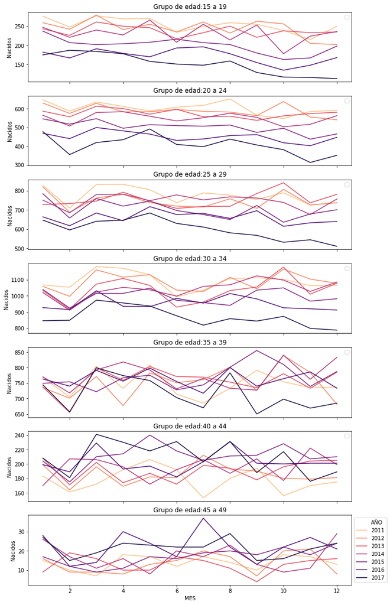

```python
# grafico por mes, los datos para cada grupo de edad desde 15 a 49 años, con color mas oscuro para los años mas recientes
palette = sns.color_palette("magma_r", 7)
fig, axes = plt.subplots(7, 1, figsize=(11, 20), sharex=True)
for name, ax in zip([15, 20, 25,30,35,40,45], axes):
      sns.lineplot(data=poredad, x='MES', y=name, ax=ax,hue='AÑO',palette=palette)
      ax.set_ylabel('Nacidos')
      ax.set_title('Grupo de edad:' +str(name)+' a '+str(name+4))
      handles,labels = ax.get_legend_handles_labels()
      ax.legend(handles[:0], labels[:0])
plt.legend(bbox_to_anchor=(1, 1))
```

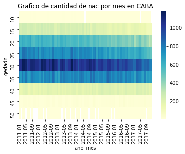

```python
#grafico las series con heatmap
df['ano_mes'] = df['mesano'].apply(lambda x: x.strftime('%Y-%m'))

# %%
sal=df[(df.provres=='CABA')].pivot_table(index=('gedadn'),columns='ano_mes',values='fecnac',dropna=False,aggfunc=pd.Series.count)
ax = sns.heatmap(sal,cmap="YlGnBu").set_title('Grafico de cantidad de nac por mes en CABA')
```

**En estos graficos se observa que para los grupos de edad 10 a 14 y 50 en adelante, la cantidad de nacidos vivos es muy baja, por lo que se analizará de 15 a 49 Además, el grupo con mayor frecuencia en CABA es el de 30 a 34 años. La cantidad de nacimientos en cada mes en 2017 es menor a la de todos los otros años en los grupos de edad de 15 a 34.**

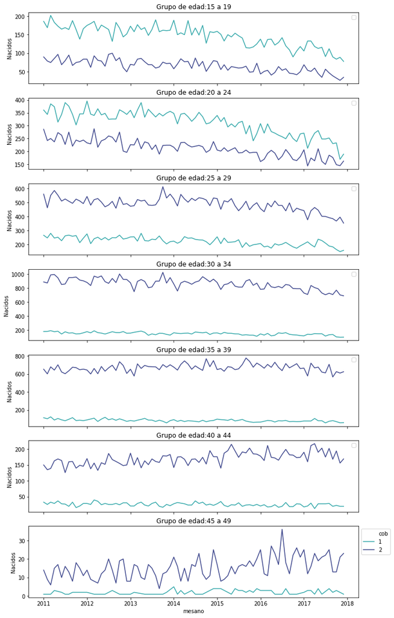

```python
#Grafico de los datos de cada grupo de edad dividos por tipo de cobertura:1 publica exclusiva y 2 otra cobertura
poredad2=df[(df.provres=='CABA')].pivot_table(index=[('mesano'),('cob')],columns='gedadn',values='fecnac',aggfunc=pd.Series.count)
poredad2.reset_index(inplace=True)
palette = sns.color_palette("mako_r", 2)
fig, axes = plt.subplots(7, 1, figsize=(11, 20), sharex=True)
for name, ax in zip([15, 20, 25,30,35,40,45], axes):
      sns.lineplot(data=poredad2, x='mesano', y=name, ax=ax,hue='cob',palette=palette)
      ax.set_ylabel('Nacidos')
      ax.set_title('Grupo de edad:' +str(name)+' a '+str(name+4))
      handles,labels = ax.get_legend_handles_labels()
      ax.legend(handles[:0], labels[:0])
plt.legend(bbox_to_anchor=(1, 1))
```

### Aquí repito el analisis exploratorio para Mendoza

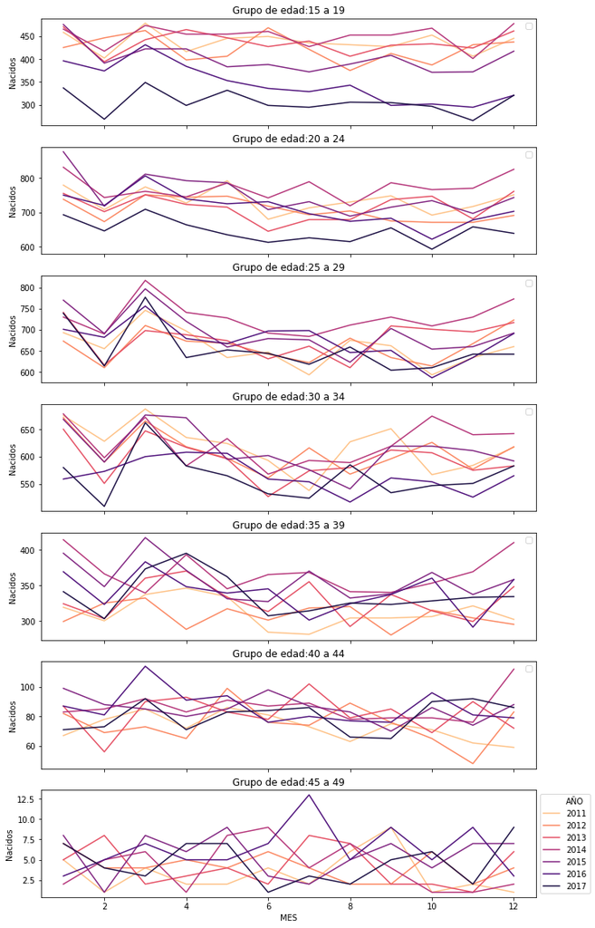

```python
# selecciono los datos de CABA y comienzo a graficar las series de tiempo por mes
poredad=df[(df.provres=='Mendoza')].pivot_table(index=('mesano'),columns='gedadn',values='fecnac',aggfunc=pd.Series.count)
poredad.head()
poredad['MES'] = poredad.index.month
poredad['AÑO'] = poredad.index.year
poredad.reset_index(level=0, inplace=True)
# grafico por mes, los datos para cada grupo de edad desde 15 a 49 años, con color mas oscuro para los años mas recientes
palette = sns.color_palette("magma_r", 7)
fig, axes = plt.subplots(7, 1, figsize=(11, 20), sharex=True)
for name, ax in zip([15, 20, 25,30,35,40,45], axes):
      sns.lineplot(data=poredad, x='MES', y=name, ax=ax,hue='AÑO',palette=palette)
      ax.set_ylabel('Nacidos')
      ax.set_title('Grupo de edad:' +str(name)+' a '+str(name+4))
      handles,labels = ax.get_legend_handles_labels()
      ax.legend(handles[:0], labels[:0])
plt.legend(bbox_to_anchor=(1, 1))
```

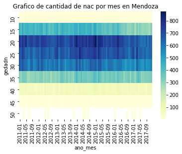

```python
#grafico las series con heatmap
sal=df[(df.provres=='Mendoza')].pivot_table(index=('gedadn'),columns='ano_mes',values='fecnac',dropna=False,aggfunc=pd.Series.count)
ax = sns.heatmap(sal,cmap="YlGnBu").set_title('Grafico de cantidad de nac por mes en Mendoza')
```

**A diferencia de la CABA, el grupo de edad con mayor cantidad de nacimientos es el de 20 a 24 años. Para Mendoza se observa que las líneas más oscuras (años más recientes) están por debajo en todos los meses en los dos primeros grupos de edad. Para el resto, no hay un patrón evidente**

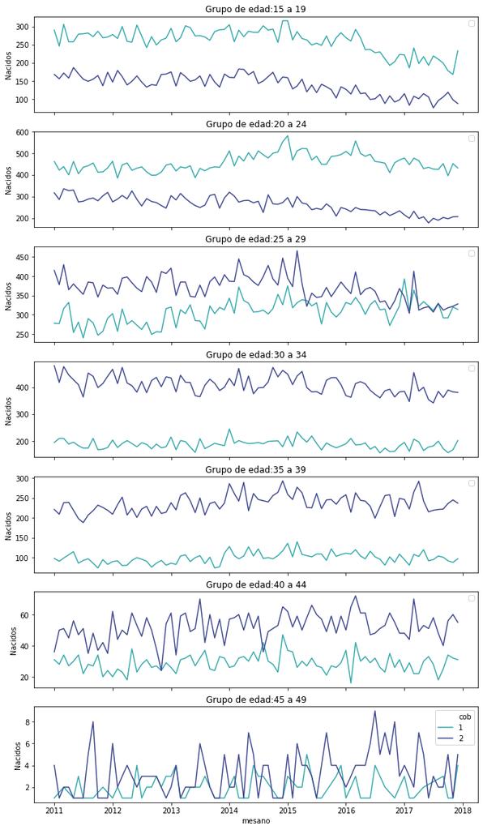

```python
poredad2=df[(df.provres=='Mendoza')].pivot_table(index=[('mesano'),('cob')],columns='gedadn',values='fecnac',aggfunc=pd.Series.count)
poredad2.reset_index(inplace=True)
palette = sns.color_palette("mako_r", 2)
fig, axes = plt.subplots(7, 1, figsize=(11, 20), sharex=True)
for name, ax in zip([15, 20, 25,30,35,40,45], axes):
      sns.lineplot(data=poredad2, x='mesano', y=name, ax=ax,hue='cob',palette=palette)
      ax.set_ylabel('Nacidos')
      ax.set_title('Grupo de edad:' +str(name)+' a '+str(name+4))
      handles,labels = ax.get_legend_handles_labels()
      ax.legend(handles[:0], labels[:0])
plt.legend(bbox_to_anchor=(1, 1))
```

## 5. Aplicación de Prophet para la detección de los puntos de cambio

```python
# Junto el grupo 40 y 45 años ya que tienen pocos casos. A los grupos  de 10 a 14  y 50 y más los asigno a 99
# que no se considerarán
cond2=[(df.gedadn==15),(df.gedadn==20),
      (df.gedadn==25) , (df.gedadn==30),
      (df.gedadn==35) , (df.gedadn==40) | (df.gedadn==45),
      (df.gedadn==10) | (df.gedadn==50)]
asig2=np.array((15,20,25,30,35,40,99),dtype='int8')
df['gedad2']=np.select(cond2,asig2,-1)
```

### Comienzo con Facebook Prophet para la detección de los puntos de cambio

```python
#Importo las librerias
from fbprophet import Prophet
from fbprophet.plot import add_changepoints_to_plot
```

```python
# Análisis para CABA: selecciono variables y renombro según lo que pide Prophet
m=df[(df['provres']=='CABA') & (df['gedad2']!=99)].groupby(['gedad2','cob','mesano'],as_index=False).fecnac.count()
m.rename(columns={'mesano':'ds','fecnac':'y'},inplace=True)
```

```python
# Defino el modelo con estacionalidad multiplicativa, puntos de corte en el 95% de la extensión de la serie
# Al hiperparámetrod changepoint_prior_scale le asigno el valor 0.5
# Genero una funcion que me devuelve las fechas, la tendencia y los estimados
# también obtengo los puntos de corte definidos y el porcentaje de cambio en cada punto de corte
def mod_prophet(serie):
    model = Prophet(yearly_seasonality=True,
                    changepoint_range=0.95,changepoint_prior_scale=0.5,
                    seasonality_mode='multiplicative')
    model.fit(serie)
    forecast = model.make_future_dataframe(periods=0, freq = 'M')
    forecast = model.predict(forecast)
    fig = model.plot(forecast)
    ax = add_changepoints_to_plot(fig.gca(), model, forecast)
    cambios=pd.concat([model.changepoints.reset_index()['ds'],pd.Series(model.params['delta'][0],name='cambio')],axis=1)
    #obs_est=pd.concat([forecast[['ds', 'trend', 'yhat']],serie['y']],axis=1)
    return forecast[['ds', 'trend', 'yhat']],cambios,fig
```

[output not shown]

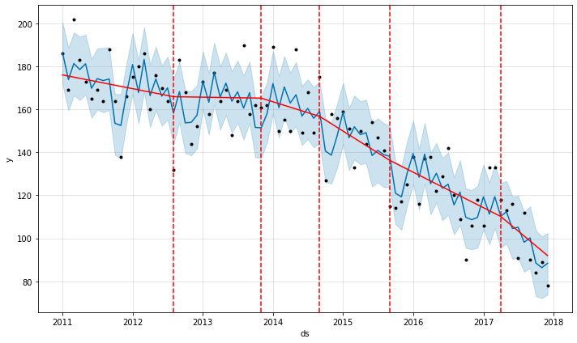

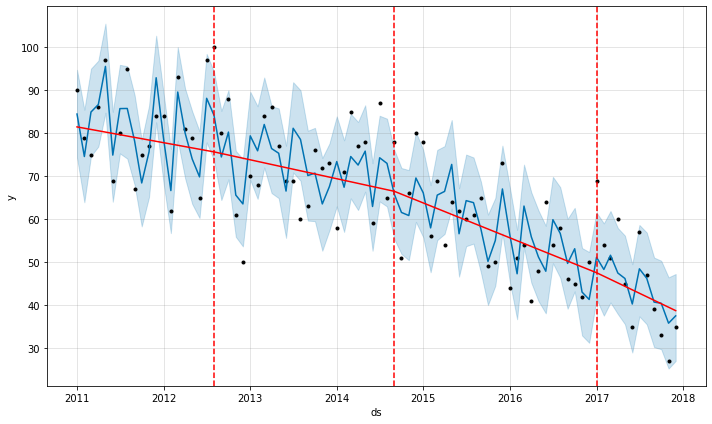

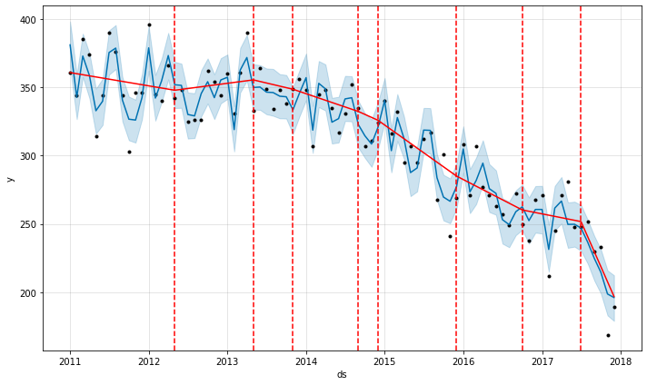

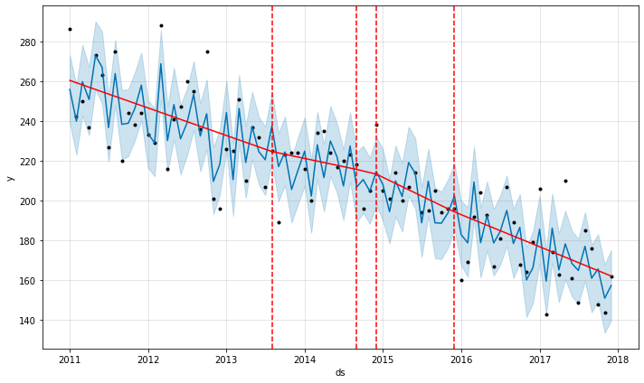

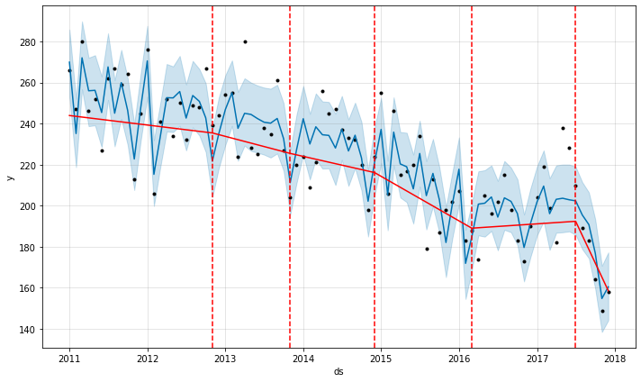

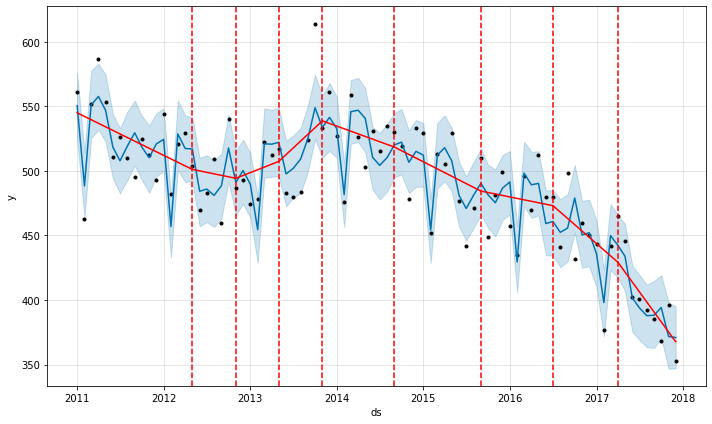

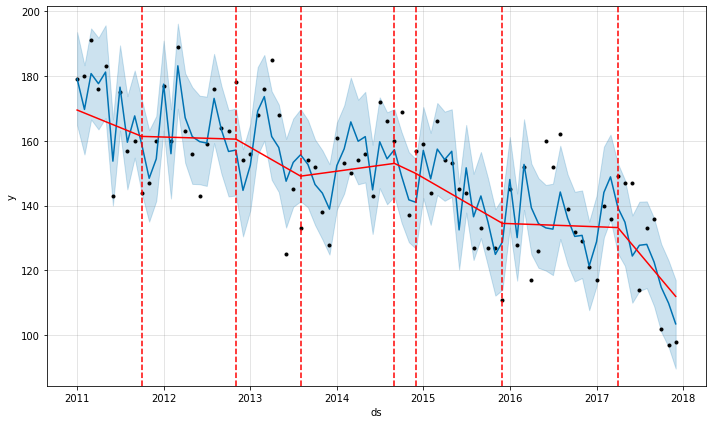

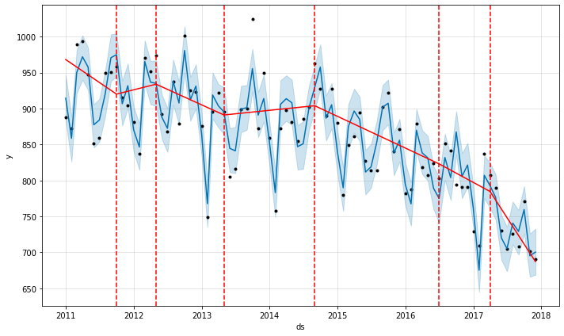

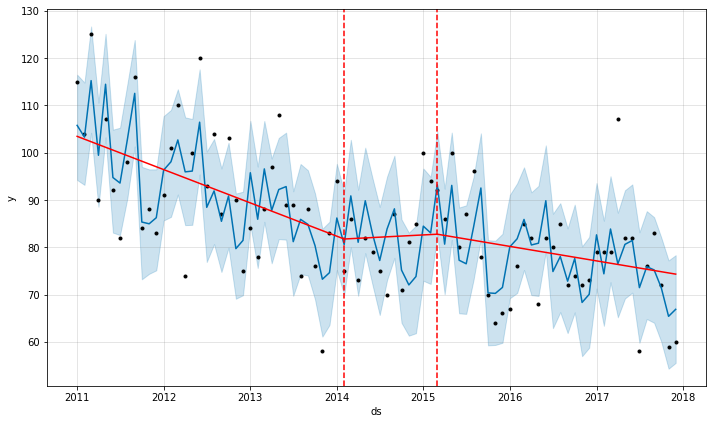

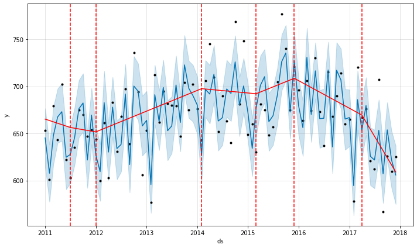

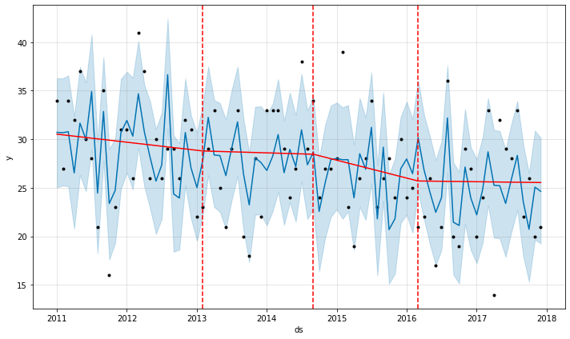

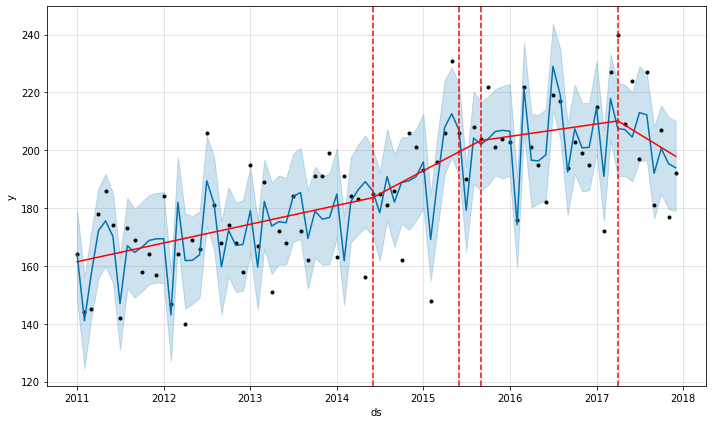

```python
# Aplico la funcion a cada grupo de edad y cobertura de salud para CABA
fcst_todoest=pd.DataFrame()
fcst_todoptos=pd.DataFrame()
prov='CABA'
for name,group in m.groupby(['gedad2','cob']):
    res_est,res_ptos,res_graf=mod_prophet(group)
    res_est['grupo']='edad'+str(name[0])+'cob'+str(name[1])
    res_ptos['grupo']='edad'+str(name[0])+'cob'+str(name[1])
    fcst_todoest=pd.concat([fcst_todoest,res_est])
    fcst_todoptos=pd.concat([fcst_todoptos,res_ptos])
    res_graf.savefig('salidas/graficos/' + prov + '/edad'+str(name[0])+'cob'+str(name[1]) + '.jpg')
```

```python
#Guardo los resultados
fcst_todoest.to_csv('salidas/resultados/CABA/modprophet1.csv',index=False)
fcst_todoptos.to_csv('salidas/resultados/CABA/ptosprophet1.csv',index=False)
```

### Muestro los puntos de cambio mayores a 10%, luego grafico un ejemplo de comparación entre los dos grupos de cobertura, para mujeres de 15 a 19 años

```python
# Puntos de cambio en tendencia mayores a 10%  y porcentaje de cambio en cada grupo
fcst_todoptos[abs(fcst_todoptos['cambio'])>0.10]
```

[output not shown]

```python
#Creo dos variables , edad y cob a partir de grupo, para facilitar cortes
fcst_todoptos['edad']= fcst_todoptos['grupo'].str[:6]
fcst_todoptos['cob']= fcst_todoptos['grupo'].str[6:10]
```

```python
#Selecciono el grupo de edad 15 a 19
corte=fcst_todoptos[fcst_todoptos['edad']=='edad15']
df15=corte.pivot_table(index='ds',columns='cob',values='cambio').reset_index()
df15['ds'] = df15['ds'].dt.strftime('%Y-%m')
```

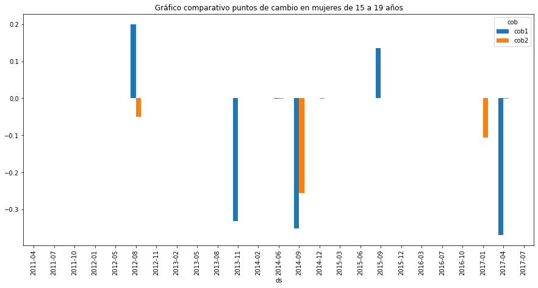

```python
# Ejemplo de gráfico para comparar puntos de cambio en mujeres de 15 a 19 años
fig=pepe.set_index('ds').plot(kind='bar', y=['cob1', 'cob2'],figsize=(15, 7))
fig.set_title('Gráfico comparativo puntos de cambio en mujeres de 15 a 19 años')
```

### Prueba de cross validation para dos modelos aplicados al grupo de CABA, 15 a 19 años sin cobertura

A modo ejemplo, se ajustan dos modelos, uno con estacionalidad multiplicativa y otro aditiva a la serie correspondiente a CABA para mujeres de 15 a 19 años, sin cobertura de salud

La forma de especificar los paramtros de cross validation la obtuve de https://github.com/facebook/prophet/issues/586 en version para R. La transforme a los parámetros de la versión python Para un período inicial de 5 años y horizonte y periodo de 2 meses cross_validation(profm, horizon =2*365/12, units = "days", period = 2*365/12,initial = 5*12*(365/12))

Se especifica un horizonte de 1 mes, con periodo de 1 mes sin embargo, al ser una serie mensual, hay discusion sobre la forma de definir los cortes. **Esta seccion es preliminar,a modo de prueba y será revisada con el tutor**

```python
# Cargo las funciones que necesito y preparo los datos
from fbprophet.diagnostics import cross_validation
from fbprophet.diagnostics import performance_metrics

m15=df[(df['provres']=='CABA') & (df['gedad2']==15) & (df['cob']==1)].groupby(['gedad2','cob','mesano'],as_index=False).fecnac.count()
m15.rename(columns={'mesano':'ds','fecnac':'y'},inplace=True)
```

```python
#Modelo 1 con estacionalidad multiplicativa
model1 = Prophet(yearly_seasonality=True,
                changepoint_range=0.95,changepoint_prior_scale=0.5,
                seasonality_mode='multiplicative')
model1.fit(m15)

crossval1= cross_validation(model1, horizon ='30.41667 days', period = '30.41667 days',initial ='1825 days')
#Calculo el MAPE
metricas= performance_metrics(crossval1,rolling_window=1,metrics=['mape'])
metricas
```

```
INFO:fbprophet:Disabling weekly seasonality. Run prophet with weekly_seasonality=True to override this.
INFO:fbprophet:Disabling daily seasonality. Run prophet with daily_seasonality=True to override this.
INFO:fbprophet:Making 18 forecasts with cutoffs between 2015-12-31 03:59:59.424000 and 2017-10-31 13:59:59.712000
```

|  | horizon | mape |
| --- | --- | --- |
| 0 | 30 days 10:00:00.288000 | 0.127942 |

```python
#Modelo 2 con estacionalidad additiva
model2 = Prophet(yearly_seasonality=True,
                changepoint_range=0.95,changepoint_prior_scale=0.5,
                seasonality_mode='additive')
model2.fit(m15)

crossval2= cross_validation(model2, horizon ='30.41667 days', period = '30.41667 days',initial ='1825 days')
#Calculo el MAPE
metricas= performance_metrics(crossval2,rolling_window=1,metrics=['mape'])
metricas
```

```
INFO:fbprophet:Disabling weekly seasonality. Run prophet with weekly_seasonality=True to override this.
INFO:fbprophet:Disabling daily seasonality. Run prophet with daily_seasonality=True to override this.
INFO:fbprophet:Making 18 forecasts with cutoffs between 2015-12-31 03:59:59.424000 and 2017-10-31 13:59:59.712000
```

|  | horizon | mape |
| --- | --- | --- |
| 0 | 30 days 10:00:00.288000 | 0.13493 |

**El modelo con estacionalidad multiplicativa tiene un MAPE levemente inferior**